# Notebook

```python
%matplotlib inline
import pandas as pd
import numpy as np
from pandas import DataFrame
import matplotlib.pyplot as plt
plt.style.use('ggplot')
```

```python
df_hn = pd.read_json('../data/hanoi_hotels.json')
df_nt = pd.read_json('../data/nhatrang_hotels.json')
df_pq = pd.read_json('../data/phuquoc_hotels.json')
print df_hn.describe()
print df_nt.describe()
```

```
         latitude   longitude  roomCapacity  totalReviews
count  384.000000  384.000000    384.000000    384.000000
mean   105.844014   21.031439     44.510417     93.833333
std      0.016491    0.010663     58.508082    131.180454
min    105.767548   20.964776      5.000000      1.000000
25%    105.844943   21.029169     20.000000     12.000000
50%    105.848533   21.032081     28.500000     37.000000
75%    105.851961   21.034705     44.000000    128.500000
max    105.919463   21.072179    445.000000    915.000000
         latitude   longitude  roomCapacity  totalReviews
count  197.000000  197.000000    197.000000    197.000000
mean   109.197080   12.237390     62.406091     57.472081
std      0.007356    0.017211     91.630233     81.328042
min    109.186884   12.133687      5.000000      1.000000
25%    109.194655   12.232183     18.000000     10.000000
50%    109.195881   12.235661     34.000000     28.000000
75%    109.198375   12.240540     70.000000     63.000000
max    109.246202   12.295176    850.000000    452.000000
```

```python
print 'Two-star hotel with very poor rating'
df_nt[df_nt.starRating.map(lambda(x): '2' in x) & df_nt.avgReviewScore.map(lambda(x): x < '6.0')]
```

```
Two-star hotel with very poor rating
```

|  | avgReviewScore | city | country | effectiveDate | latitude | longitude | name | roomCapacity | starRating | state | street | streetnumber | suburb | topNationCounts | topNationNames | totalReviews |
| --- | --- | --- | --- | --- | --- | --- | --- | --- | --- | --- | --- | --- | --- | --- | --- | --- |
| 59 | 5.8 |  |  | 2015-07-24 | 109.189088 | 12.249266 | Quang An Hotel | 20 | 2-star hotel |  |  |  |  | [1] | Belgium | 6 |
| 85 |  |  |  | 2015-07-24 | 109.193963 | 12.236287 | Long Beach Hotel | 28 | 2-star hotel |  |  |  |  | [1] | United Kingdom | 2 |
| 105 |  |  |  | 2015-07-24 | 109.194038 | 12.235883 | Botanic Hotel | 24 | 2-star hotel |  |  |  |  | [1] | United Kingdom | 2 |
| 106 |  |  |  | 2015-07-24 | 109.192995 | 12.245533 | Minh Thanh Hotel | 40 | 2-star hotel |  |  |  |  | [1] | Thailand | 4 |
| 121 | 5.9 |  |  | 2015-07-24 | 109.199834 | 12.227331 | Seaside 2 Hotel | 27 | 2-star hotel |  |  |  |  | [5, 1] | Vietnam,Canada | 32 |
| 122 |  |  |  | 2015-07-24 | 109.186884 | 12.236573 | Modern Sky Hotel | 25 | 2-star hotel |  |  |  |  | [1] | United Kingdom | 2 |
| 123 | 4.1 |  |  | 2015-07-24 | 109.199161 | 12.228172 | Glory Dragon Hotel | 20 | 2-star hotel |  |  |  |  | [1] | Russia | 8 |
| 127 |  |  |  | 2015-07-24 | 109.199480 | 12.226791 | Thien Nga Family Hotel | 26 | 2-star hotel |  |  |  |  | [1] | Australia | 4 |
| 134 |  |  |  | 2015-07-24 | 109.196666 | 12.233910 | Merlion Hotel | 25 | 2-star hotel |  |  |  |  | [1] | Singapore | 3 |
| 145 |  |  |  | 2015-07-24 | 109.191407 | 12.239014 | Viet Sea Hotel | 21 | 2-star hotel |  |  |  |  | [1] | United Kingdom | 1 |
| 147 | 5.8 |  |  | 2015-07-24 | 109.192061 | 12.240896 | Pha Le Xanh 2 Hotel | 30 | 2-star hotel |  |  |  |  | [3, 2, 1, 1] | Australia,Vietnam,Canada,Russia | 20 |
| 164 | 5.9 |  |  | 2015-07-24 | 109.189671 | 12.245433 | Pha Le Xanh Hotel | 30 | 2-star hotel |  |  |  |  | [3, 1] | Netherlands,United Kingdom | 10 |
| 165 | 4.9 |  |  | 2015-07-24 | 109.192584 | 12.251551 | Hoa Dao Hotel | 28 | 2-star hotel |  |  |  |  | [1] | Australia | 7 |
| 179 |  |  |  | 2015-07-24 | 109.191651 | 12.241187 | Phuong Nhung Hotel | 40 | 2-star hotel |  |  |  |  | [1] | United States of America | 4 |
| 180 | 5.7 |  |  | 2015-07-24 | 109.190342 | 12.255824 | Phu Thinh Hotel | 30 | 2-star hotel |  |  |  |  | [1, 1] | Canada,Thailand | 10 |
| 186 | 5.5 |  |  | 2015-07-24 | 109.196723 | 12.218678 | Vu Quy Hotel | 30 | 2-star hotel |  |  |  |  | [1, 1] | Australia,Norway | 8 |

## Room capacities

### Total room capacity

```
Ha Noi:  17092
Nha Trang:  12294
Phu Quoc:  3543
```

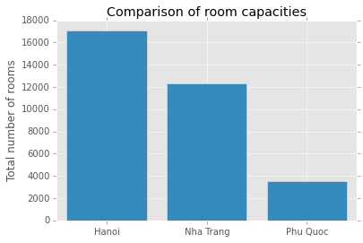

```python
hn = df_hn.roomCapacity.sum()
nt = df_nt.roomCapacity.sum()
pq = df_pq.roomCapacity.sum()
print 'Ha Noi: ', hn
print 'Nha Trang: ', nt
print 'Phu Quoc: ', pq

plt.bar((1, 2, 3), (hn, nt, pq), align='center')
plt.xticks((1, 2, 3), ('Hanoi', 'Nha Trang', 'Phu Quoc'))
plt.ylabel('Total number of rooms')
plt.title('Comparison of room capacities')
```

### Distribution

We can divide hotels into 3 categories based on their capacity: small (0 - 50 rooms), medium (50 - 100 rooms), large (over 100 rooms). There are a few hotels in all regions with very large capacity (over 300 rooms), these are exceptions and we ignore in this analysis.

It's clear from the distribution that most hotels in Hanoi and Nha Trang are small. Although in Nha Trang the market for medium to large hotels is bigger.

Hypothesis: land is less expensive in Nha Trang than HN; hotels in Nha Trang more spread out.

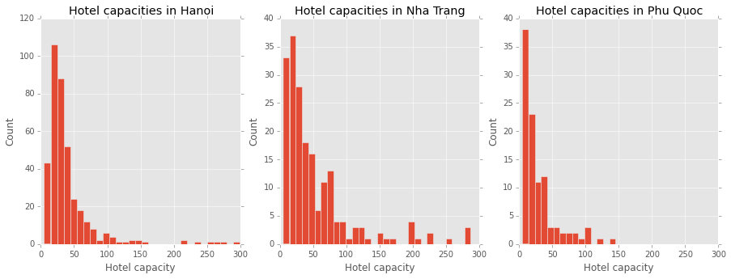

```python
from scipy import stats

plt.figure(figsize = (15, 5))

plt.subplot(131)
out = plt.hist(df_hn.roomCapacity[df_hn.roomCapacity < 300], bins = 30)
plt.xlabel('Hotel capacity')
plt.ylabel('Count')
plt.title('Hotel capacities in Hanoi')

plt.subplot(132)
plt.hist(df_nt.roomCapacity[df_nt.roomCapacity < 300], bins = 30)
plt.xlabel('Hotel capacity')
plt.ylabel('Count')
plt.title('Hotel capacities in Nha Trang')

plt.subplot(133)
plt.hist(df_pq.roomCapacity[df_pq.roomCapacity < 300], bins = 15)
plt.xlim([0, 300])
plt.xlabel('Hotel capacity')
plt.ylabel('Count')
plt.title('Hotel capacities in Phu Quoc')
```

## Hotel grade

```python
def convert_rating(x):
    if ' hotel' in x:
        return x.split()[0]
    elif 'stars' in x:
        return "%s-star" % x.split()[0]

def get_ratings(df):
    ratings = df.starRating.astype(np.string_)
    ratings = ratings[ratings != '']
    return ratings.map(convert_rating)
```

### Percentage of star-ratings

Consistent with our analysis on the hotel capacity, 2-star and 3-star hotels dominate all cities. There are still many 1-star hotels in both Nha Trang and Phu Quoc, so it'll be interesting to see how that develops into the future. My prediction is that the number of 1-star hotels in Nha Trang, driving the distribution to be more or less equivalent to Hanoi.

Opportunity: find 1-star hotels with very low rating (in crowded area) and buy them, then upgrade

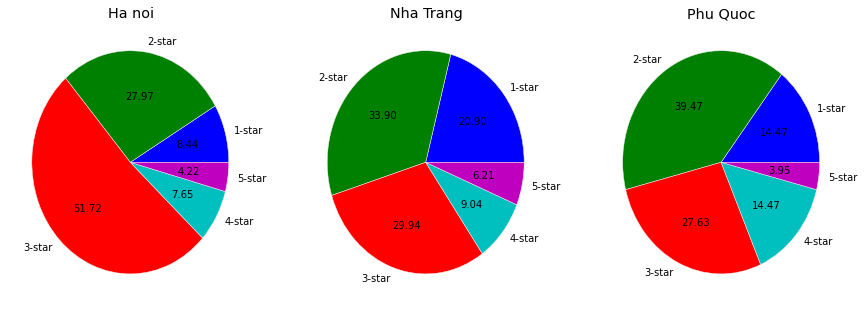

```python
plt.figure(figsize = (15, 5))

ratings = get_ratings(df_hn).value_counts().sort_index()
plt.subplot(131)
plt.pie(ratings.values, labels = ratings.index, autopct = '%.2f')
plt.title('Ha noi')

ratings = get_ratings(df_nt).value_counts().sort_index()
plt.subplot(132)
plt.pie(ratings.values, labels = ratings.index, autopct = '%.2f')
plt.title('Nha Trang')

ratings = get_ratings(df_pq).value_counts().sort_index()
plt.subplot(133)
plt.pie(ratings.values, labels = ratings.index, autopct = '%.2f')
plt.title('Phu Quoc')
```

## Rated quality based on reviews

TODO: review scores across different hotel stars?

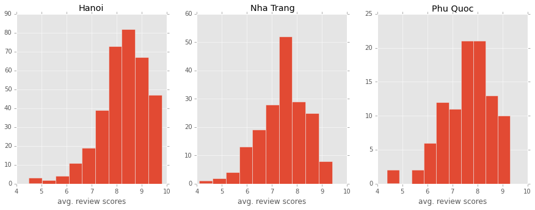

```python
def plot_review_scores(df, sp):
    scores = df.ix[df.avgReviewScore != '', 'avgReviewScore'].astype(np.float32)
    plt.subplot(sp)
    plt.hist(scores)
    plt.xlabel('avg. review scores')
    return scores

plt.figure(figsize = (15, 5))
plot_review_scores(df_hn, 131)
plt.title('Hanoi')

plot_review_scores(df_nt, 132)
plt.title('Nha Trang')

plot_review_scores(df_pq, 133)
plt.title('Phu Quoc')
```

Hotels in Hanoi are rated higher on average, indicating that the market is more competitive there. There are still opportunities for Nha Trang and Phu Quoc.

## Guest nationalities

This can be biased toward English-speaking countries because some website only show reviews based on the viewer's location.

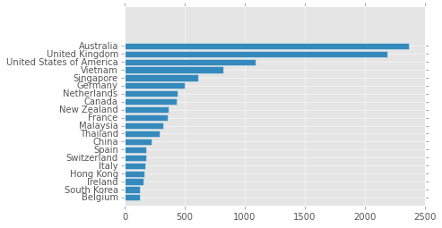

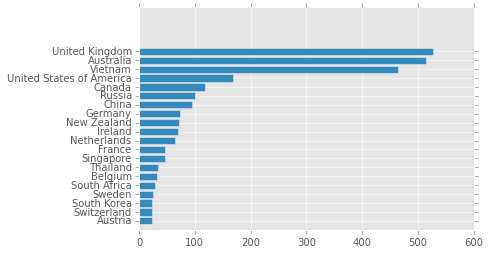

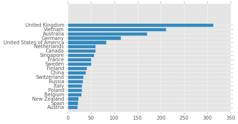

```python
from collections import Counter

def to_int(xs):
    return [int(x) for x in xs]

def get_nation_counts(df):
    c = Counter()
    for (i, names) in enumerate(df.topNationNames):
        counts = df.topNationCounts.values[i]
        counts = counts.replace('[', '').replace(']','')
        d = dict(zip(names.split(','), to_int(counts.split(','))))
        c.update(d)
    return c

def plot_nation_counts(df, top=20):
    counter = zip(*(get_nation_counts(df).most_common(top)))
    pos = np.arange(len(counter[0]), 0, -1)
    plt.barh(pos, counter[1], align='center')
    plt.yticks(pos, counter[0])

plt.figure()
plot_nation_counts(df_hn, 20)
plt.figure()
plot_nation_counts(df_nt, 20)
plt.figure()
plot_nation_counts(df_pq, 20)
```

## Location

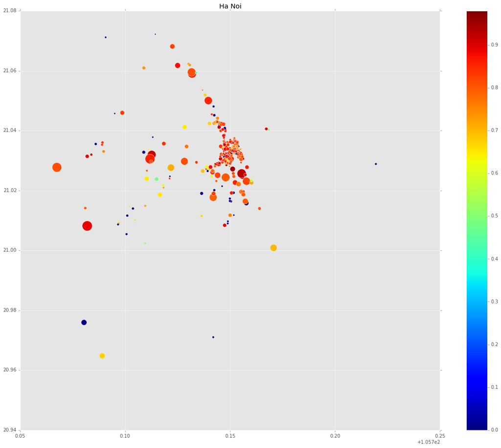

```python
#plt.figure(figsize = (15, 5))

def color_map(score):
    if score != '':
        return float(score) / 10
    else:
        return 0
plt.figure(figsize = (20, 16))
plt.scatter(df_hn.latitude, df_hn.longitude, s=df_hn.roomCapacity,
            c=df_hn.avgReviewScore.map(color_map))
plt.title('Ha Noi')
plt.colorbar()
```

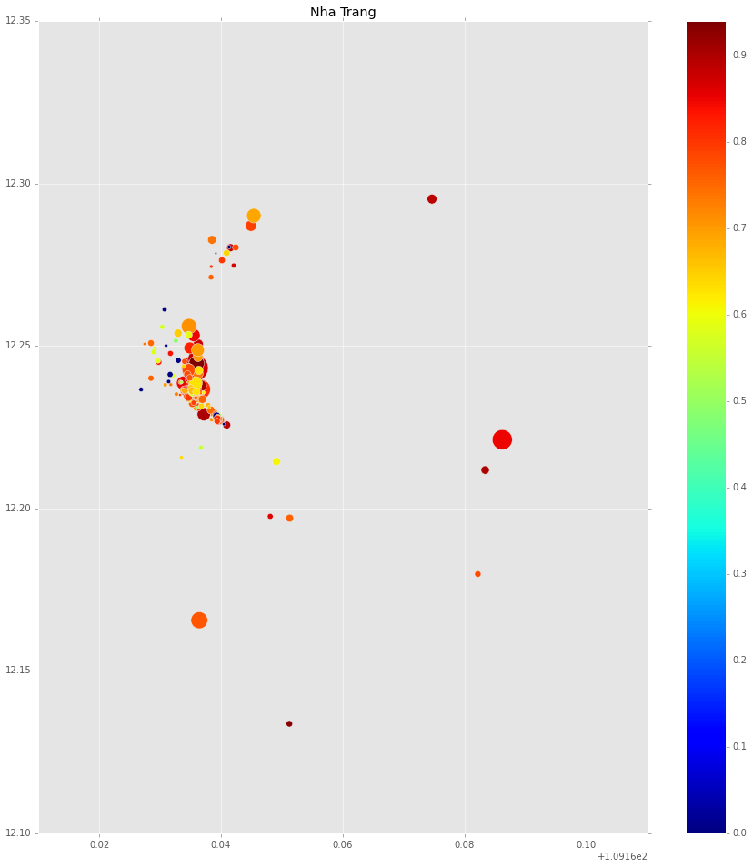

```python
plt.figure(figsize = (15, 16))
plt.scatter(df_nt.latitude, df_nt.longitude, s=df_nt.roomCapacity,
            c=df_nt.avgReviewScore.map(color_map))
plt.title('Nha Trang')
plt.colorbar()
```

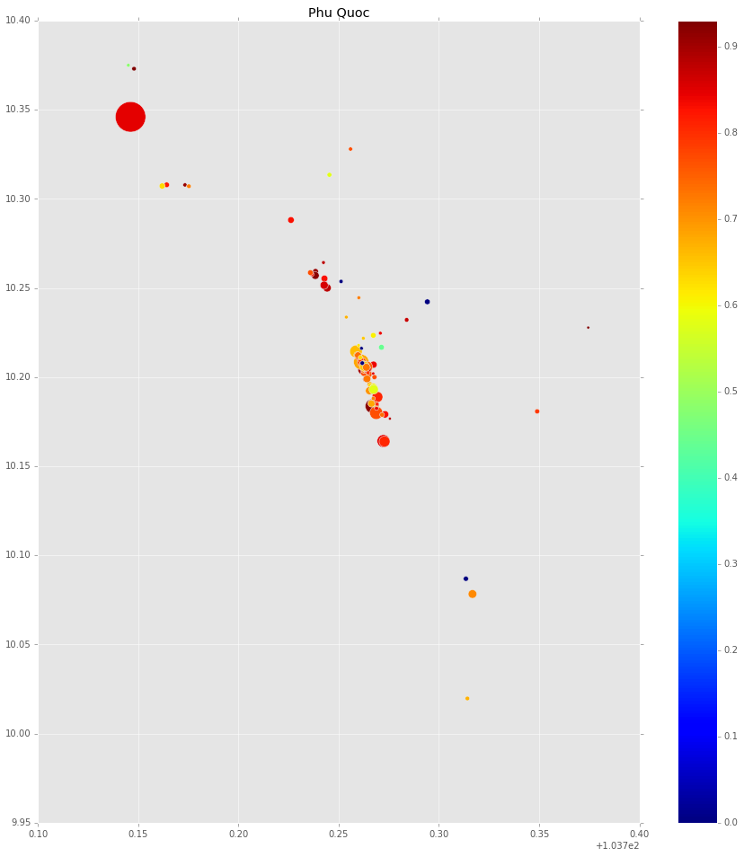

```python
plt.figure(figsize = (15, 16))
plt.scatter(df_pq.latitude, df_pq.longitude, s=2*df_pq.roomCapacity,
            c=df_pq.avgReviewScore.map(color_map))
plt.title('Phu Quoc')
plt.colorbar()
```